# Tarea 1 - IN5162-1, Semestre Primavera 2023

Joaquin Urbina, Damián De Aguiar.

07 septiembre, 2023

**Curso:** Ingeniería de Marketing, Marcel Goic

**Equipo Docente:** Joaquín Cisternas, Ignacio Hernández, Andrés Olivares, Agustín Hilcker

## Enunciado

Las inequidades de género se manifiestan en disitintas áreas de la economía y existe evidencia que apunta a que [el ingreso de los hombres es mayor que el de las mujeres en casi todo el mundo](https://ourworldindata.org/economic-inequality-by-gender/#in-most-countries-there-is-a-substantial-gender-pay-gap). En objetivo de esta tarea es entender si esta brecha se presenta en pequeños comercios, dónde la literatura sugiere [la participación de mujeres ha crecido significativamente en las últimas décadas](https://www.tandfonline.com/doi/full/10.1111/j.1540-627X.2007.00214.x)

Para estudiar las brechas de género, usaremos los datos de una plataforma de pagos digitales con amplia cobertura en pequeños comercios. La plataforma registra todos los pagos digitales de una muestra de 5 mil comercios en una región en Latinoamericano que no podemos revelar. Los pagos digitales se realizan en un dispositivo de cobro que procesa la información de las tarjetas de crédito y/o débito de los clientes de los comercios y administra el pago digitalmente. Para usar el servicio, los comercios deben comprar el dispositivo que procesa los pagos el que queda registrado a cargo de un o una responsable comercial sobre quién se conoce el domicilio y el género. Como la muestra corresponde a comercios que en general tienen baja facturación, es razonable asumir que quién registra el dispositivo es quién en general opera el negocio, lo que nos posibilita estudiar brechas de ingreso.

La base de datos que hemos recopilado para estudiar las brechas de género contiene una caracterización del comercio, y variables de actividad econoómica semanal como ingresos, numero de transacciones y horas trabajadas:

- **idm**: Número del vendedor(a)
- **zona**: String con id de la zona.
- **semana**: Corresponde a la semana del año del registro.
- **Año**: Corresponde al año del registro.
- **semana_Año**: String que une las columnas semana y año (formato: semana-Año)
- **edad**: Edad del vendedor(a).
- **genero**: Toma el valor 1 si es mujer y 0 si es hombre.
- **ingreso**: Ingresos percibidos por el vendedor(a) i en la semana w del año y.
- **dias_trabajados**: Días trabajados por el vendedor(a) i en la semana w del año y.
- **antiguedad**: Antigüedad (en años) del vendedor i utilizando SumUp.
- **rubro**: Rubro del negocio del vendedor i.
- **transacciones**: Cantidad de transacciones que hizo el vendedor(a) i en la semana w del año y.
- **hrs_trabajados**: Horas trabajadas por el vendedor(a) i en la semana w del año y.
- **cuarentena1**: 1 si hubo cuarentena algún dia activo del vendedor(a) i en la semana w del año y, 0 si no.
- **hrs_diarias**: Horas diarias promedio trabajadas en los días que el vendedor(a) i trabajó en la semana w del año y.
- **transacciones_hr**: Promedio de transacciones por hora realizadas por el vendedor(a) i en la semana w del año y.
- **ingreso_hr**: Ingresos por hora promedio percibidos por el vendedor(a) i en la semana w del año y.

A partir surgen una serie de preguntas de investigación interesantes. ¿Existe una brecha de ingresos para este segmento de comerciantes? De existir, ¿cuál es su magnitud y qué tanta dispersión existe? ¿Es homogénea entre rubros y zonas? ¿Qué podría explicar esta potente diferencia en los ingresos?

#### **Reglas del juego**

- Las tareas buscan replicar parcialmente las labores a las que se enfrentarían en el análisis de datos para el apoyo en la toma de decisiones, ya sea para una organización o para la definición de políticas. Por esto, se han propuesto preguntas relativamente abiertas que requieren que ustedes discutan y decidan cuál es el mejor enfoque de solución. Les pedimos que se involucren tempranamente en el desarrollo de la tarea para tener una discusión enriquecedora.
- Todas las dudas, comentarios y errores publicarlos **exclusivamente** en el foro de u-cursos. De esta forma todos se benefician de las respuestas ofrecidas.
- Consideramos que es muy importante que logren escribir un informe conciso con una redacción acorde de un informe técnico profesional. La presentación y comunicación de resultados es parte integral de la tarea y, por tanto, será evaluada cuidadosamente.
- La tarea se desarrolla en grupos de máximo 3 integrantes. El entregable principal es un único markdown separado en tabs (a través de la opción .tabset). En un primer tab incluya todo el desarrollo de la tarea adecuadamente comentado. El segundo tab incluya el resumen de sus resultados de acuerdo a lo pedido en la pregunta 6. Este segundo tab es el que usarán en caso de que les corresponda presentar sus resultados. Considere también un tab con todos los procedimientos preliminares y otro para los anexos dónde puede incluir cualquier resultado complementario.
- Para entregar sus resultados suba, vía u-cursos, un único archivo comprimido llamado t1-A1-A2-A3.zip, donde A1, A2 y A3 es el primer apellido de los integrantes del grupo. Incluya también los nombres de los integrantes en el documento mismo. Incluya en el zip tanto el archivo .html de salida del markdown como los códigos fuentes que permitan reproducir sus resultados.
- Para la pregunta final consideramos que 4 figuras son suficientes para resumir los aprendizajes más relevantes, pero si están convencidos de que agregar una figura adicional es absolutamente necesaria, ¡Adelante!
- La fecha de entrega de la tarea es el jueves 7 de septiembre a las 23:59, sin excepciones y no habrá plazo extra para la entrega. Si por algún motivo de fuerza mayor se ve imposibilitado de entregar la tarea en el plazo estipulado, deberá escribir directamente al profesor explicando su situación. El profesor decidirá el curso de acción de acuerdo a los méritos del caso. Como siempre, es mejor dar cuenta de cualquier problema con la mayor anticipación posible.
- Recuerde que tenemos dos instancias de retroalimentación asociadas a la tarea:
  1. La sesión, a realizarse el día viernes 1 de septiembre, está destinada para que expongan sus avances y dificultades y podamos discutir colectivamente cuáles son causes de acción razonables para resolver los problemas. A esta fecha se espera que los grupos al menos hayan explorado los datos y estimado algunos modelos preliminares.
  2. La sesión, a realizarse el día viernes 8 de septiembre, está destinada a que expongan los resultados más relevantes de su trabajo y resuman sus principales aprendizajes. Esta instancia busca simular una presentación final contra una contraparte interesada, como a las que se enfrentarán frecuentemente en su vida profesional.

Aunque me gustaría que todos pudieran presentar, no tenemos tiempo para aquello por lo solo seleccionaremos a aquellos que encuentren valor en esta instacia de aprendizaje. Las presentaciones tendrán una duración aproximada de 10 minutos y no es necesario que preparen material adicional. La salida del markdown debe ser lo suficientemente explicativa para comunicar sus resultados.

- A raíz de la opinión de los estudiantes, vamos a implementar una co-evaluación para que los estudiantes puedan valorar la participación de los compañeros y compañeras de grupo. Para calcular la nota final del alumno $j$ ponderaremos la nota grupal por $\max \left\{ \frac{J \cdot prom_j}{\sum_{k=1}^J prom_k} , 0.75 \right\}$, donde $prom_k$ corresponde al promedio de las co-evaluaciones recibidas por el estudiante $k$ dentro del grupo de $J$ integrantes.
- El equipo docente considera que la copia de tareas atenta en contra de tu aprendizaje y por tanto aplicará todas las medidas que estén a su disposición para desincentivar esta mala práctica.

## Preliminares

Escriba acá todos los comandos que necesita ejecutar antes de abordar las preguntas de la tarea (carga de librerías, lectura de datos, limpieza de la data, transformación de variables y todo lo que necesite).

#### Preparación Tarea

[output not shown]

[output not shown]

| idm | zona | semana | año | semana_año | edad | genero | ingreso | dias_trabajados | antiguedad | rubro | transacciones | hrs_trabajadas | cuarentena1 | hrs_diarias | transacciones_hr | ingreso_hr |
| --- | --- | --- | --- | --- | --- | --- | --- | --- | --- | --- | --- | --- | --- | --- | --- | --- |
| 1668 | zona 7 | 1 | 2020 | 1-2020 | 24 | 0 | 82300 | 4 | 1 | Comida Rápida | 20 | 12 | 0 | 3.000000e+00 | 1.666667e+14 | 6.858333e+14 |
| 1668 | zona 7 | 1 | 2021 | 1-2021 | 25 | 0 | 235700 | 5 | 2 | Comida Rápida | 26 | 15 | 1 | 3.000000e+00 | 1.733333e+14 | 1.571333e+14 |
| 1668 | zona 7 | 2 | 2020 | 2-2020 | 24 | 0 | 182900 | 5 | 1 | Comida Rápida | 24 | 14 | 0 | 2.800000e+01 | 1.714286e+14 | 1.306429e+14 |
| 1668 | zona 7 | 2 | 2021 | 2-2021 | 25 | 0 | 197000 | 6 | 2 | Comida Rápida | 22 | 16 | 1 | 2.666667e+14 | 1.375000e+03 | 1.231250e+05 |
| 1668 | zona 7 | 2 | 2022 | 2-2022 | 26 | 0 | 8500 | 1 | 3 | Comida Rápida | 2 | 2 | 0 | 2.000000e+00 | 1.000000e+00 | 4.250000e+03 |
| 1668 | zona 7 | 3 | 2020 | 3-2020 | 24 | 0 | 188350 | 5 | 1 | Comida Rápida | 26 | 11 | 0 | 2.200000e+01 | 2.363636e+14 | 1.712273e+14 |

## Desarrollo

Documente acá el desarrollo de su tarea por pregunta.

### Pregunta 1

(1.0 puntos) Explore los datos para entender como se comportan los ingresos de acuerdo al género del comerciante y liste al menos 3 variables que podrían influir en la brecha de ingresos. Justifique la elección de estas variables en base a los resultados del ejericio de exploración de datos.

### 1.

#### Vemos datos generales de la data

```
##       idm           zona               semana           año
##  Min.   :   1   Length:248395      Min.   : 1.00   Min.   :2018
##  1st Qu.: 882   Class :character   1st Qu.:15.00   1st Qu.:2020
##  Median :1738   Mode  :character   Median :28.00   Median :2021
##  Mean   :1753                      Mean   :27.04   Mean   :2021
##  3rd Qu.:2647                      3rd Qu.:39.00   3rd Qu.:2022
##  Max.   :3509                      Max.   :53.00   Max.   :2022
##   semana_año             edad           genero          ingreso
##  Length:248395      Min.   :18.00   Min.   :0.0000   Min.   :      50
##  Class :character   1st Qu.:35.00   1st Qu.:0.0000   1st Qu.:   41200
##  Mode  :character   Median :44.00   Median :1.0000   Median :  125000
##                     Mean   :44.84   Mean   :0.5873   Mean   :  276681
##                     3rd Qu.:54.00   3rd Qu.:1.0000   3rd Qu.:  329475
##                     Max.   :80.00   Max.   :1.0000   Max.   :19595800
##  dias_trabajados   antiguedad       rubro           transacciones
##  Min.   :1.000   Min.   :0.000   Length:248395      Min.   :   1.00
##  1st Qu.:3.000   1st Qu.:0.000   Class :character   1st Qu.:   5.00
##  Median :5.000   Median :1.000   Mode  :character   Median :  16.00
##  Mean   :4.462   Mean   :1.262                      Mean   :  36.26
##  3rd Qu.:6.000   3rd Qu.:2.000                      3rd Qu.:  43.00
##  Max.   :8.000   Max.   :5.000                      Max.   :1182.00
##  hrs_trabajadas    cuarentena1       hrs_diarias        transacciones_hr
##  Min.   :  1.00   Min.   :0.00000   Min.   :1.000e+00   Min.   :1.000e+00
##  1st Qu.:  4.00   1st Qu.:0.00000   1st Qu.:3.000e+00   1st Qu.:1.000e+00
##  Median : 12.00   Median :0.00000   Median :3.400e+01   Median :1.594e+05
##  Mean   : 18.13   Mean   :0.08984   Mean   :1.529e+14   Mean   :8.592e+13
##  3rd Qu.: 27.00   3rd Qu.:0.00000   3rd Qu.:2.667e+14   3rd Qu.:1.463e+14
##  Max.   :106.00   Max.   :1.00000   Max.   :9.857e+14   Max.   :9.933e+14
##    ingreso_hr
##  Min.   :5.000e+01
##  1st Qu.:1.500e+04
##  Median :1.060e+14
##  Mean   :2.131e+14
##  3rd Qu.:3.581e+14
##  Max.   :1.000e+15
```

#### Frecuencia de datos por edad

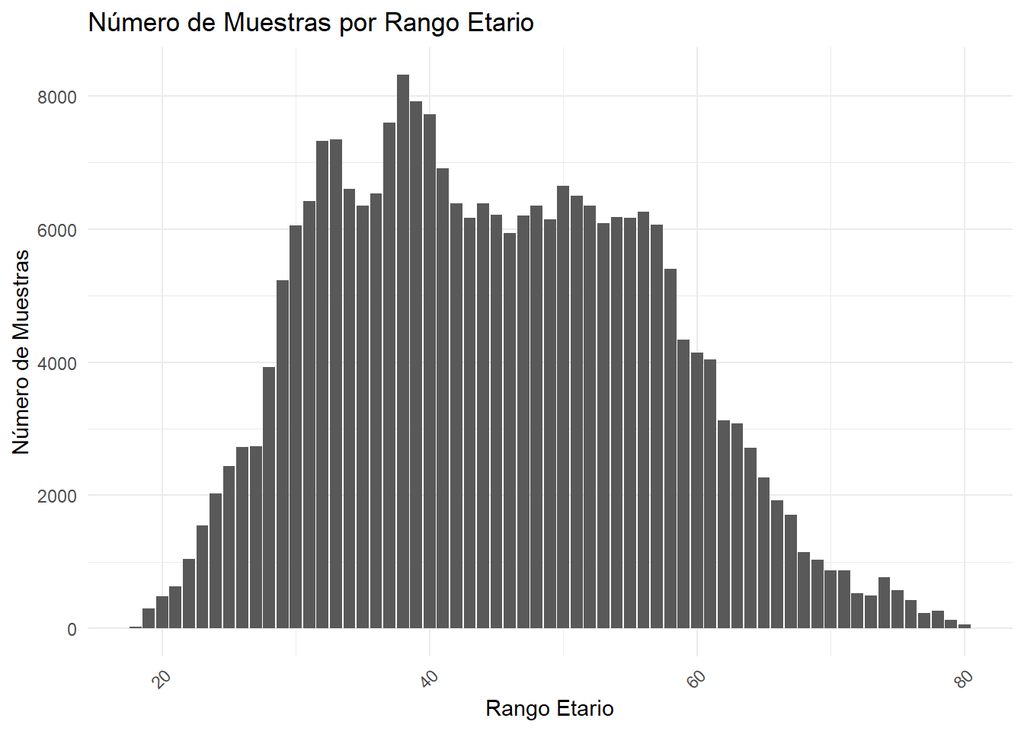

```r
ggplot(mersample, aes(x = edad)) +
  geom_bar() +
  labs(title = "Número de Muestras por Rango Etario", x = "Rango Etario", y = "Número de Muestras") +
  theme_minimal() +
  theme(axis.text.x = element_text(angle = 45, hjust = 1))
```

##### R- Notamos como los datos se centran entre los 30 a 60 años, fuera de ese rango pueden haber problemas en las observaciones debido a la baja cantidad de datos.

#### Vemos distribución de ingresos

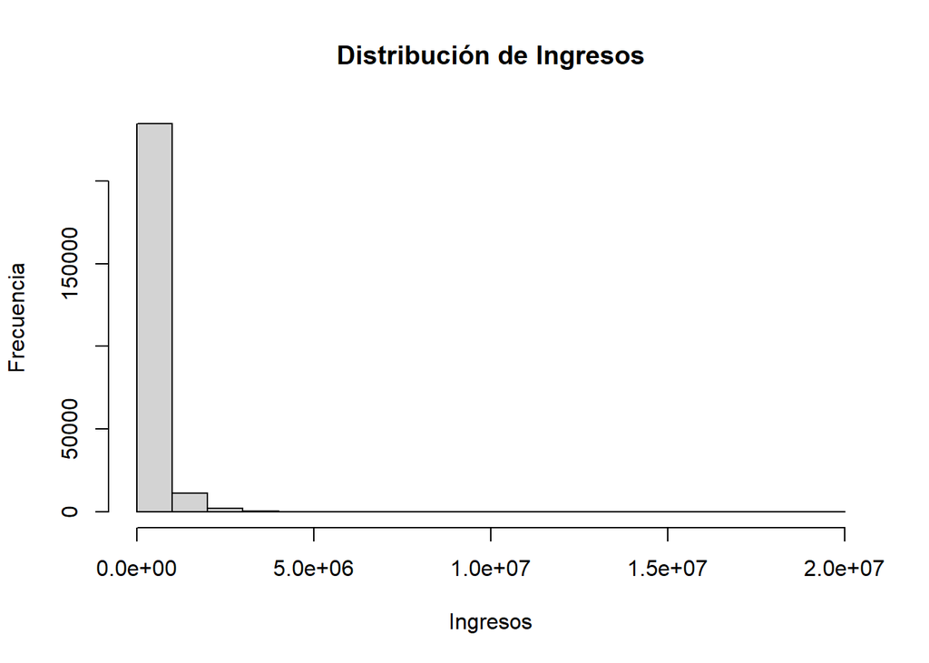

##### R- Notamos como la dispersion de los datos es muy grande, lleganiod a ingresos de 19 millones.

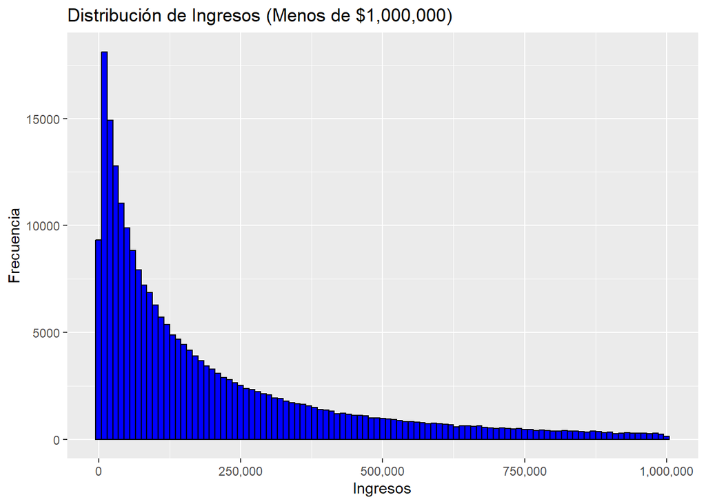

#### Gráfico de ingresos X género X edad (para ver ingreso total)

```r
# Calcular el promedio de ingresos por edad y género
ingresos_promedio <- ventas %>%
  group_by(edad, genero) %>%
  summarize(ingreso_promedio = mean(ingreso))
```

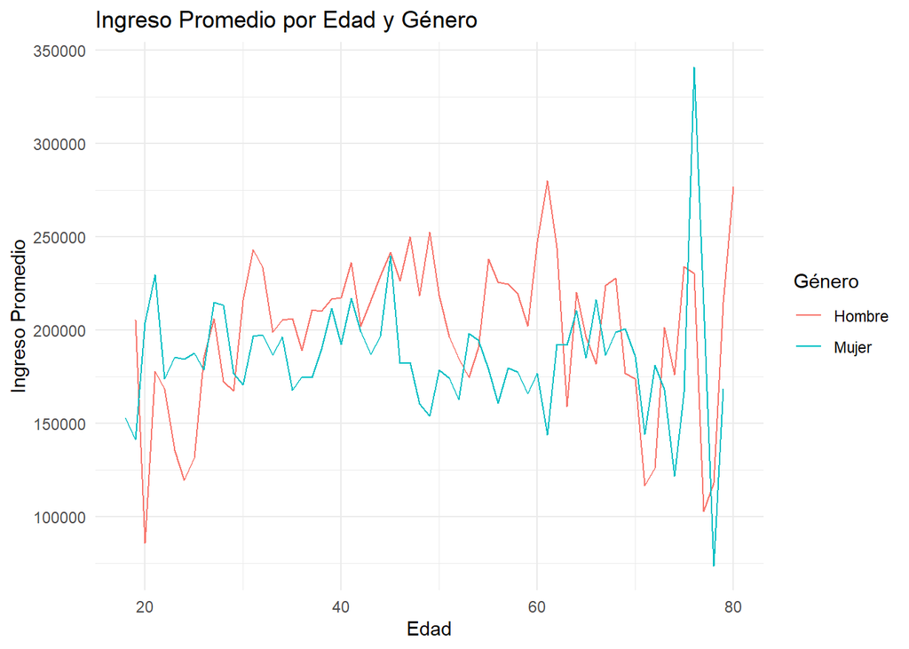

```r
# Crear un gráfico de líneas
ggplot(ingresos_promedio, aes(x = edad, y = ingreso_promedio, color = factor(genero))) +
  geom_line(aes(group = genero)) +
  labs(title = "Ingreso Promedio por Edad y Género",
       x = "Edad", y = "Ingreso Promedio") +
  scale_color_discrete(name = "Género", labels = c("Hombre", "Mujer")) +
  theme_minimal()
```

##### R- Notamos como existe una tendencia de los hombres a tener mayores ingresos que las mujeres.

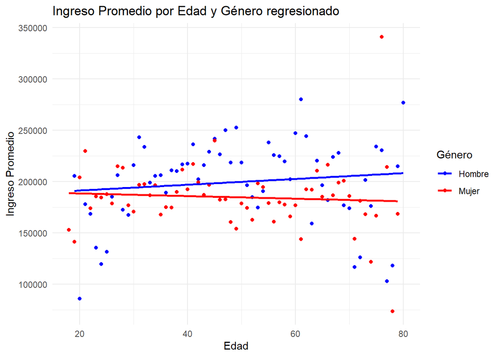

##### R- Los puntos indican el promedio de ingreso para una edad determinada. Se aprecia con las líneas de regresión cómo la brecha de ingreso tiende a hacerse mayor a medida que las personas tienen más edad.

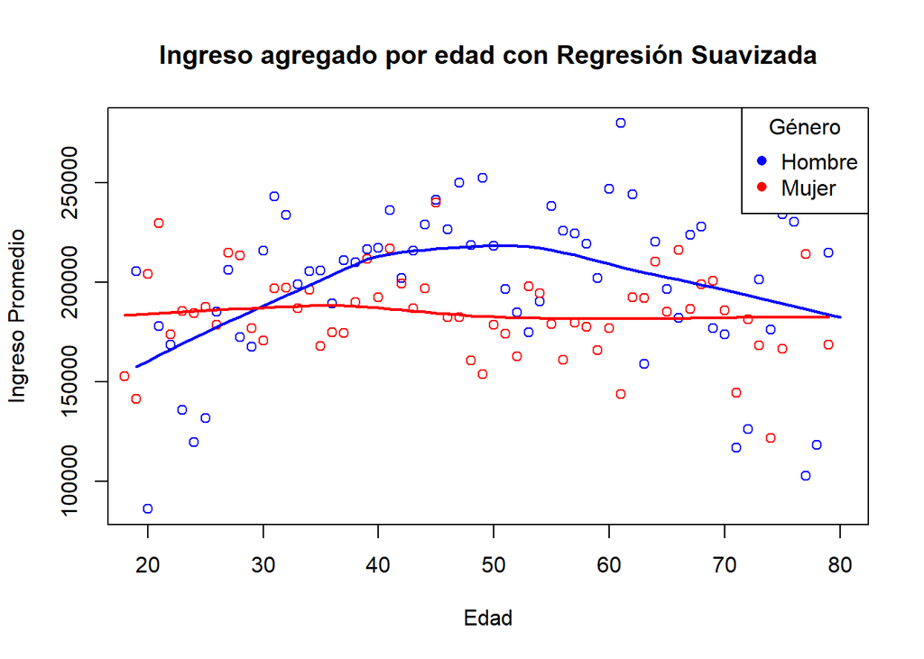

##### R- Al replicar el gráfico anterior pero con una regresion suavizada dado la gran dispersion existente especialmente en edades de los extremos para los que hay pocos datos en la muestra. Se observa cómo la brecha de ingreso se produce por un aumento del ingreso del hombre más que una variación en el de la mujer. A su vez se observa cómo la brecha disminuye pasado los 55 añosm esto se puede deber al efecto de la jubilación o retiro.

Usando el df agregado por edad:

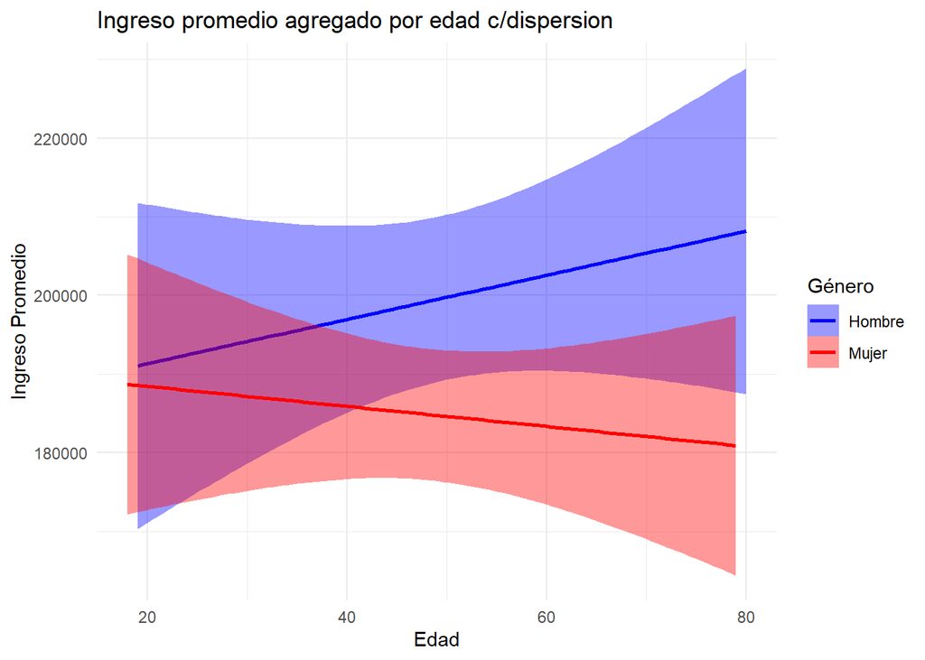

```r
# Gráfico con ggplot2 que muestra líneas de intervalos de confianza con colores diferentes por género


ggplot(ingresos_promedio, aes(x = edad, y = ingreso_promedio, color = factor(genero), fill = factor(genero))) +
  ggtitle("Ingreso promedio agregado por edad c/dispersion") +
  xlab("Edad") +
  ylab("Ingreso Promedio") +
  geom_smooth(method = "lm", se = TRUE) +
  scale_color_manual(values = c("blue","red"), labels = c("Hombre", "Mujer")) +  # Etiquetas de los colores
  scale_fill_manual(values = c("blue","red"), labels = c("Hombre", "Mujer")) +    # Etiquetas de los colores
  labs(color = "Género", fill = "Género") +  # Cambio de nombres de las leyendas de colores
  theme_minimal()
```

##### R- Con este gráfico se observa la gran dispersion que existe especialmente entre ingresos entre las edades extremas, esto se debe al bajo número de datos para estas edades.

#### Sacamos promedios de ingreso en todos los datos

```
## El ingreso promedio entre hombres es: 210626.9
```

```
## El ingreso promedio entre muejres es: 185608.5
```

```
## Los hombres ganan en promedio: 13.47913 % más que las mujeres
```

#### Horas diarias trabajadas X genero X edad (para ver cuanto trabaja cada género)

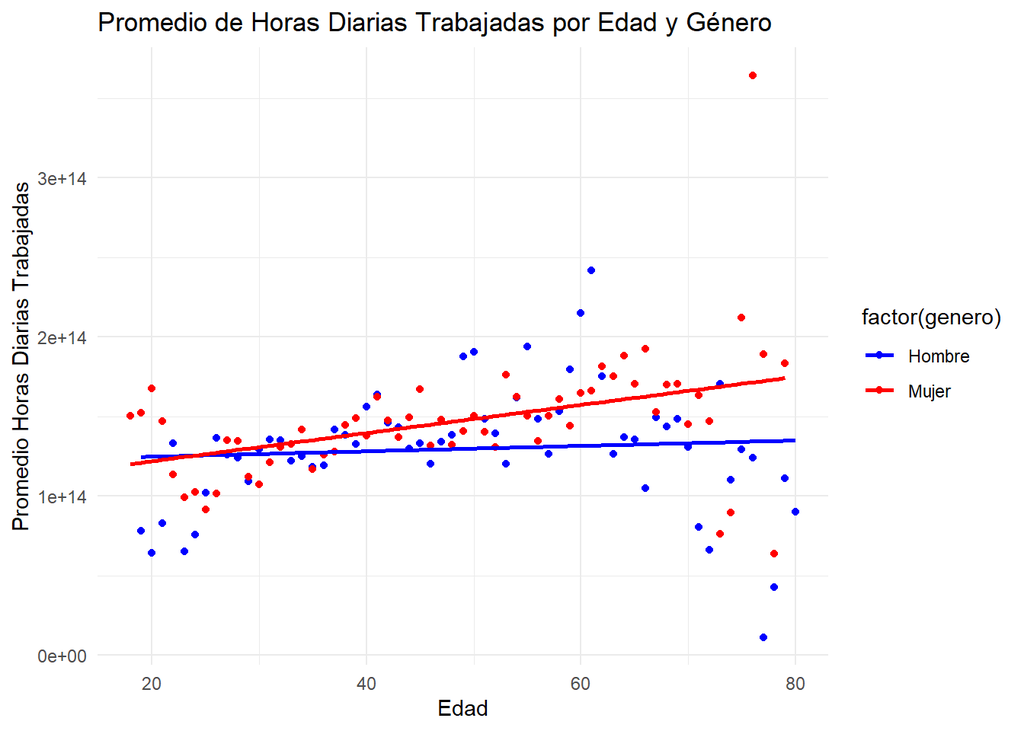

##### R- Acá vemos cómo las mujeers tienden a trabajar más horas diarias a medida que crecen y los hombres se mantienen relativamente igual en el tiempo. Es especialmente curioso al compararlo con el grafico anterior ya que las muejres tienden a ganar menos en el tiempo.

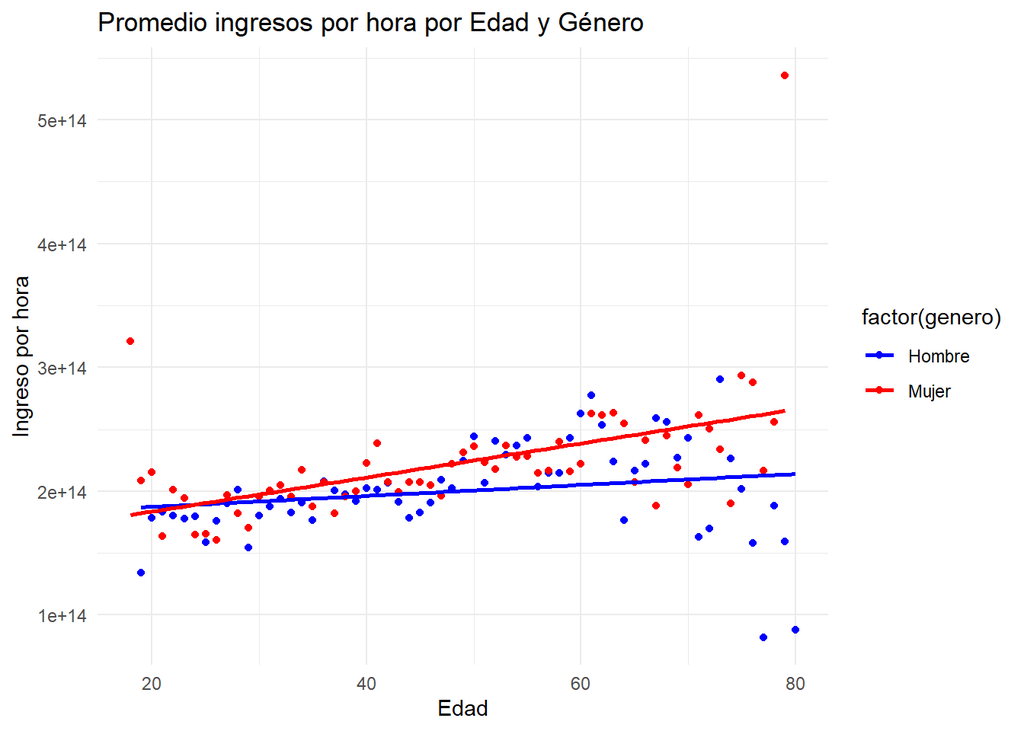

##### R- Vemos que el ingreso que logran por hora es cada vez mayor en mujeres a lo largo del tiempo, osea que aumentan su productividad cosa que en hombres crece menos. Especialmente curioso al ver que el ingreso total semanal de las mujeres disminuye en el tiempo.

#### Horas semanales trabajadas X genero X edad (para ver cuanto trabaja cada género)

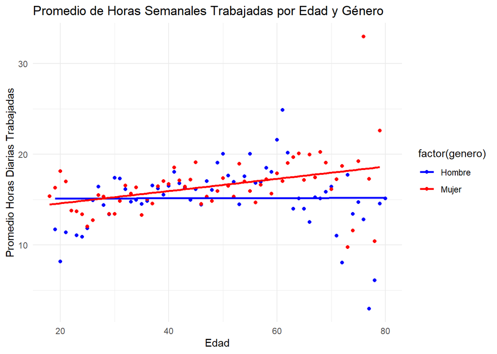

##### R- Notamos al agregar por edad, las mujeres tienden a trabajar más a medida que crecen, mientras los hombres trabajan siempre lo mismo.

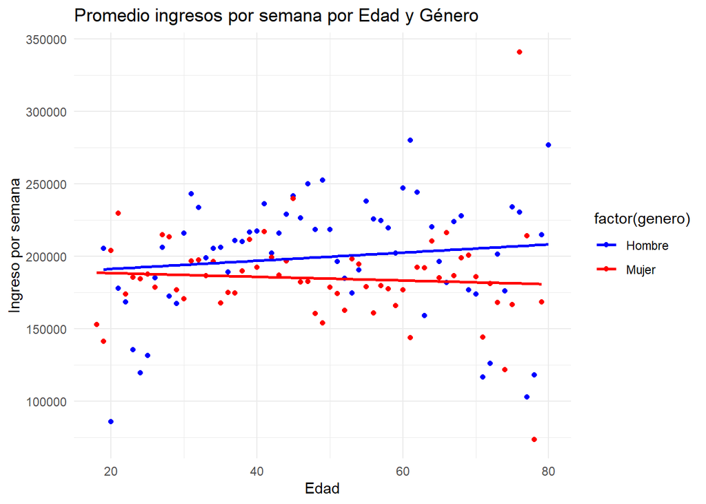

##### R- Sin embargo, a pesar de trabajar más a la semana, las muejres ganan menos que los hombres. Esto brecha se acrecenta en el tiempo lo que significa que a medida que las mujeres aumentan su cantidad de horas trabajadas, su ingreso disminuye.

#### Ahora obtenemos los promedios generales de las horas trabajdas, sin agregar por edad.

```
## Los hombres trabajan en promedio 16.28169 horas a la semana
```

```
## Las mujeres trabajan en promedio 16.24325 horas a la semana
```

[output not shown]

#### Gráfico de ingreso X hora trabajda X genero (así se ve productividad)

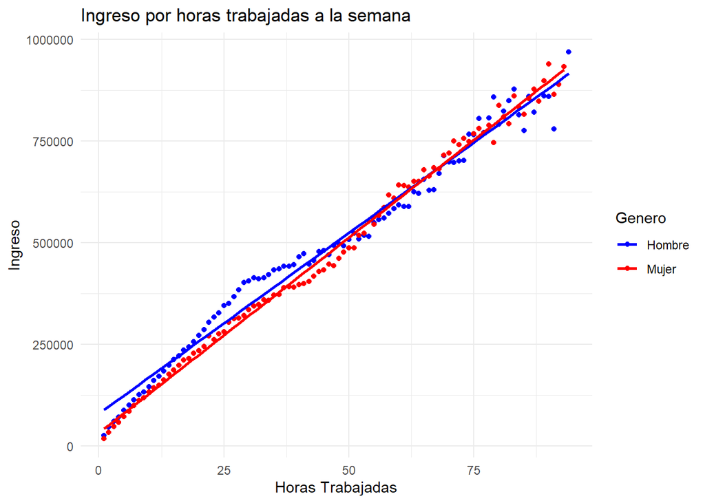

##### R- Vemos como existe una brecha en la productividad, siendo los hombres más producitvos por hora trabjada bajo al trabjar bajo 50 horas semanales. Sobre las 50 horas al tener pocos datos no es recomendable sacar una conclusión de como es la brescha a pesar de que el gráifco la muestre.

#### Grafico promedio ingreso X rubro

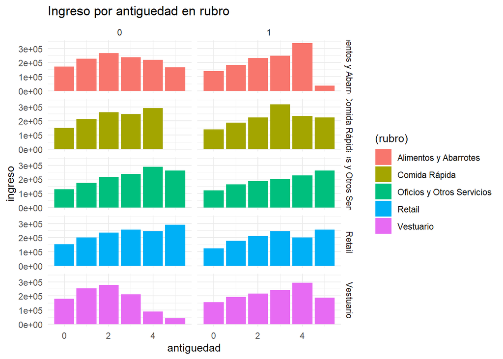

##### R- Vemos como las mujeres (columna derecha) tienden a ganar más en los rubros de “alimentas y abarrotes” y “vestuario” en el tiempo que los hombres, quienes a partir del tercer año disminuyen sus ingresos. Esto quizás se puede deber a una tendedncia de especialización.Igualmente en estos dos rubros se observa una caída en los ingresos a partir del quinto año tanto en hombres como en mujeres. Las muejres disminuyen su ingreso y se estanca en el rubro de comida rápida mientras que los hombres continúan aumentando.

#### Grafico ingreso X genero X rubro

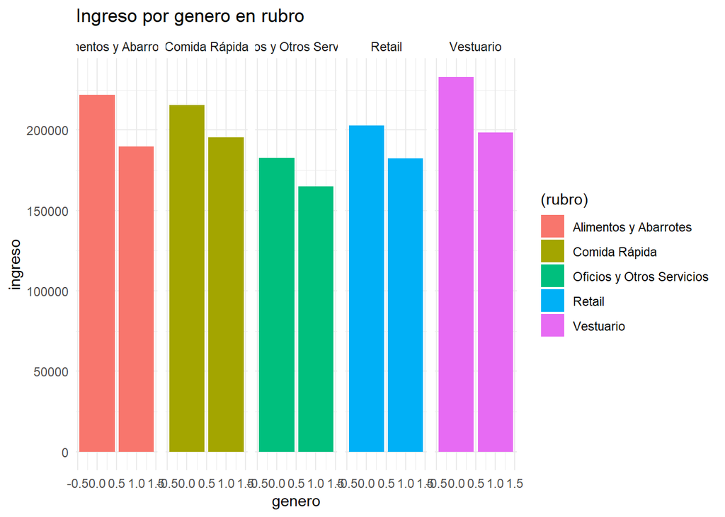

##### R- Vemos cómo los rubros de mayor ingresos en hombres son el vestuario seguido de aliemnto y abarrotes. En mujeres dónde más ganan es en vestuario y en comida rápida. Igualmente se observa que los hombres ganan más que las mujeres en todos los rubros. Esto indica que la brecha de ingreso no es propia sólo de un rubro.

#### Grafico transacciones x rubro

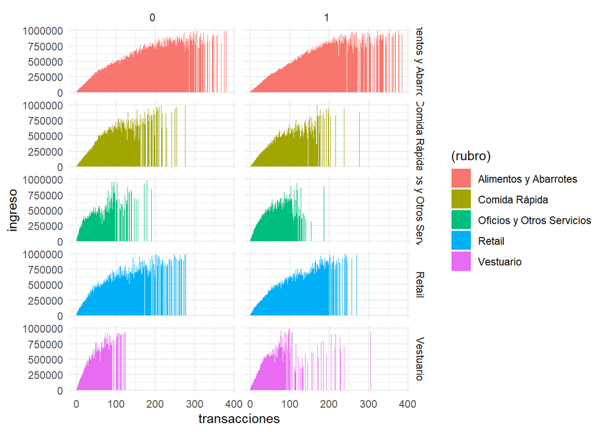

#### Pregunta 2

(1.0 puntos) Proponga al menos dos especificaciones alternativas para modelos de regresión lineal que permitan examinar cuantitativamente el tamaño de la brecha de género y compare sus resultados con respecto a un modelo que solo incluye el género como variable explicativo. Para cada modelo indique el signo esperado del efecto y justifique las diferencias encontradas entre los modelos.

|  | M1 |
| --- | --- |
| (Intercept) | 11.51***(0.00) |
| genero | -0.14***(0.01) |
| Num.Obs. | 234335 |
| R2 | 0.002 |
| R2 Adj. | 0.002 |
| RMSE | 1.45 |

|  | M3 |
| --- | --- |
| (Intercept) | 10.34***(0.01) |
| genero | -0.16***(0.01) |
| hrs_trabajadas | 0.06***(0.00) |
| antiguedad | 0.13***(0.00) |
| genero × hrs_trabajadas | 0.00***(0.00) |
| Num.Obs. | 234335 |
| R2 | 0.492 |
| R2 Adj. | 0.492 |
| RMSE | 1.03 |

Regressions with Fixed Effects

|  | m5 |
| --- | --- |
| Dependent Var.: | log(ingreso) |
| genero | -0.12* (0.03) |
| log(transacciones) | 1.04*** (0.01) |
| hrs_trabajadas | -0.01** (0.00) |
| antiguedad | 0.08* (0.02) |
| Fixed-Effects: | ————– |
| rubro | Yes |
| __________________ | ______________ |
| S.E.: Clustered | by: rubro |
| Observations | 234,335 |
| R2 | 0.748 |
| AIC | 515,599.173 |

#### Conclusiones P2

##### C- Modelo 1 base: En promedio, las mujeres tienen un ingreso un 14% menor al de los hombres. Igualmente, al tener un R ajustado bajo del 0.2%, vemos que el género es poco explicativo en la variabilidad del ingreso. Esto indica que, a pesar de tener ingresos diferentes de base para cada género, la variación de los mismos no está afectada por el género. Así, otros factores no incluidos en el modelo pueden tener un impacto más significativo en el ingreso.

M5: Se decide trabajar con el paquete fixest para tratar los errores fijos. Además, se agrega al modelo las transacciones, siendo esta una variable significativa, como también antigüedad y su variación por rubro, lo que aumenta el R cuadrado. Ahora se logra un R cuadrado del 74.8%, lo que indica un gran poder explicativo. Esto se debe a la variable de número de transacciones, que tiene una relación casi 1 a 1 con el ingreso, lo que es lógico. Se observa que las horas trabajadas ahora pierden poder de efecto sobre el ingreso. Al estar controlando por rubro, se puede concluir que el rubro no es una causa de la diferencia de ingreso. Finalmente, se concluye que si el número de transacciones es el mayor explicador del ingreso y las mujeres ganan de base un 12% menos que los hombres, se puede inferir que las mujeres están vendiendo menos unidades que los hombres, o si venden las mismas, lo hacen a un precio menor.

Hay muchas posibles causas de esto; una puede ser que el horario en que trabajan las mujeres, debido a temas de seguridad o la necesidad de llevar a sus hijos al colegio temprano, hace que se pierdan las horas más rentables del día. Otra conjetura puede ser que los hombres elijan ubicaciones mejores que las mujeres, posiblemente debido a una mayor capacidad física para competir por un espacio. Estas son solo conjeturas sobre las posibles razones que pueden estar causando las diferencias mostradas.

### Pregunta 3

(1.0 puntos) Utilice mecanismos automáticos de selección de variables para refinar los resultados de la pregunta anterior y discuta cuál de todas las especificaciones es la que mejor describe los ingresos pobservados.

#### Utilizamos primero selección automática de variables con enofque backward y foreward:

|  | backwards | forward |
| --- | --- | --- |
| (Intercept) | 9.34***(0.11) | 33.87(62.56) |
| idm | 0.00*(0.00) | 0.00*(0.00) |
| zonazona 10 | -0.12***(0.03) | -0.12***(0.03) |
| zonazona 11 | -0.13**(0.04) | -0.13**(0.04) |
| zonazona 12 | 0.23***(0.04) | 0.23***(0.04) |
| zonazona 13 | 0.13**(0.05) | 0.13**(0.05) |
| zonazona 14 | 0.16***(0.03) | 0.16***(0.03) |
| zonazona 15 | 0.11**(0.04) | 0.11**(0.04) |
| zonazona 16 | 0.13***(0.03) | 0.13***(0.03) |
| zonazona 17 | -0.05(0.03) | -0.05(0.03) |
| zonazona 18 | -0.31***(0.03) | -0.31***(0.03) |
| zonazona 19 | -0.12*(0.05) | -0.12*(0.05) |
| zonazona 2 | -0.05+(0.03) | -0.05+(0.03) |
| zonazona 20 | 0.09+(0.05) | 0.09+(0.05) |
| zonazona 21 | -0.13***(0.02) | -0.13***(0.02) |
| zonazona 22 | 0.13**(0.05) | 0.13**(0.05) |
| zonazona 23 | 0.05(0.04) | 0.05(0.04) |
| zonazona 24 | 0.22***(0.04) | 0.22***(0.04) |
| zonazona 25 | -0.02(0.05) | -0.02(0.05) |
| zonazona 26 | 0.05(0.05) | 0.05(0.05) |
| zonazona 27 | -0.06*(0.03) | -0.06*(0.03) |
| zonazona 28 | 0.21***(0.05) | 0.21***(0.05) |
| zonazona 29 | -0.07*(0.03) | -0.07*(0.03) |
| zonazona 3 | -0.08***(0.02) | -0.08***(0.02) |
| zonazona 30 | -0.13**(0.04) | -0.13**(0.04) |
| zonazona 31 | 0.29***(0.06) | 0.29***(0.06) |
| zonazona 32 | -0.09**(0.03) | -0.09**(0.03) |
| zonazona 33 | 0.09**(0.03) | 0.09**(0.03) |
| zonazona 34 | 0.37***(0.06) | 0.37***(0.06) |
| zonazona 35 | -0.11**(0.04) | -0.11**(0.04) |

[output cut: 297 more lines]

##### C- Con los resutados de la selección automática de variables, se puede observar que este modelo no es mejor que los plantedos anteriormente, por lo que no se podría considerar como mejor. Así mimso, ninguno de los des onfoques (backward y froward) es notablmente más agresivo al eliminar variables. EL planteado previament tiene un R ajustado de 74.8% vs un 65.6%. Se decide trabajar con el modelo anterior.

#### Ahora utilizamos ridge y LASSO:

Coefficients from Ridge and LASSO regressions

|  | ridge | lasso |
| --- | --- | --- |
| (Intercept) | -7.720196e+06 | -7.720082e+06 |
| idm | -3.851570e+00 | -3.851516e+00 |
| zona | 0.000000e+00 | 0.000000e+00 |
| semana | 9.994913e+02 | 9.994852e+02 |
| año | 3.837454e+03 | 3.837397e+03 |
| semana_año | 0.000000e+00 | 0.000000e+00 |
| edad | -1.334326e+03 | -1.334321e+03 |
| genero | -3.448831e+04 | -3.448824e+04 |
| dias_trabajados | 1.759127e+04 | 1.759114e+04 |
| antiguedad | 3.935524e+04 | 3.935519e+04 |
| rubro | 0.000000e+00 | 0.000000e+00 |
| transacciones | 5.637148e+03 | 5.637142e+03 |
| hrs_trabajadas | -2.667805e+03 | -2.667767e+03 |
| cuarentena1 | 3.478535e+03 | 3.478299e+03 |
| hrs_diarias | 0.000000e+00 | 0.000000e+00 |
| transacciones_hr | 0.000000e+00 | 0.000000e+00 |
| ingreso_hr | 0.000000e+00 | 0.000000e+00 |

##### C- Observamos como zona, semana_año, rubro, hrs_diarias, transacciones_hr, ingreso_hr: En ambas regresiones Ridge y LASSO, estos coeficientes son cero, lo que sugiere que estas variables no tienen un impacto significativo en la variable objetivo y pueden ser eliminadas del modelo sin afectar en gran medida la calidad de las predicciones.

semana, año, edad, genero, dias_trabajados, antiguedad, transacciones, cuarentena1, hrs_trabajadas: Estas variables tienen coeficientes distintos de cero en ambas regresiones. Dado que las únicas variables relevantes que pueden ser diferntes entre géneros son genero, antiguedad, transacciones, hrs_tabjadas y días trabajdos, vemos que puede ser valioso hacer un modelo de regresion considerando estas 5 variables.

Ninguno de los dos modelos es más agresivo eliminando variables.

### Pregunta 4

(1.0 puntos) Proponga ahora un modelo de regresión lineal que permita explicar el efecto del género en las horas trabajadas y un modelo que permita explicar el efecto del género en los ingresos por hora. Discuta la relación de estas variables dependientes con el ingreso semanal explorado en la Pregunta 2.

|  | M1 | M2 |
| --- | --- | --- |
| (Intercept) | 8.61***(0.01) | -8.21***(0.05) |
| genero | -0.14***(0.00) | 0.13***(0.03) |
| hrs_trabajadas | -0.01***(0.00) |  |
| antiguedad | 0.06***(0.00) | 0.62***(0.02) |
| rubroComida Rápida | 0.20***(0.01) | -3.62***(0.08) |
| rubroOficios y Otros Servicios | 0.79***(0.01) | -0.32***(0.07) |
| rubroRetail | 0.48***(0.01) | -1.57***(0.06) |
| rubroVestuario | 1.03***(0.01) | -1.80***(0.11) |
| log(transacciones) | 1.04***(0.00) | 9.84***(0.01) |
| genero × hrs_trabajadas | 0.00***(0.00) |  |
| antiguedad × rubroComida Rápida | 0.06***(0.00) | -0.77***(0.05) |
| antiguedad × rubroOficios y Otros Servicios | 0.09***(0.00) | -0.78***(0.04) |
| antiguedad × rubroRetail | 0.01**(0.00) | -0.48***(0.04) |
| antiguedad × rubroVestuario | -0.07***(0.01) | -0.69***(0.07) |
| Num.Obs. | 234335 | 234335 |
| R2 | 0.749 | 0.782 |
| R2 Adj. | 0.749 | 0.782 |
| RMSE | 0.73 | 7.33 |

### Pregunta 5

(1.0 puntos) Use al menos dos de los modelos de aprendizaje de máquinas que vimos en clases (MARS, kNN, regression tree, random forest) para describir el nivel de ingresos de los comercios. Compare sus resultados con los derivados de los modelos anteriores. Además, utizando el o los modelos que les parezcan adecuados, realice un pronóstico del ingreso semanal de un vendedor para cada rubro y género.

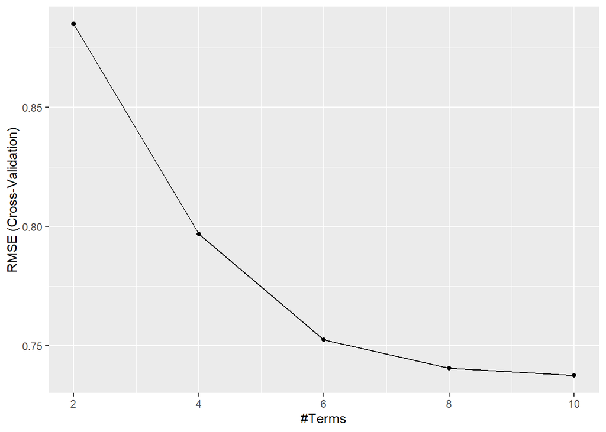

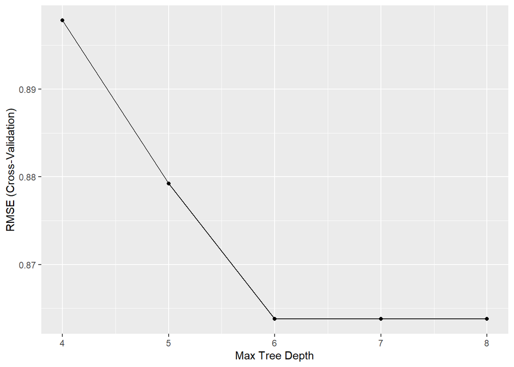

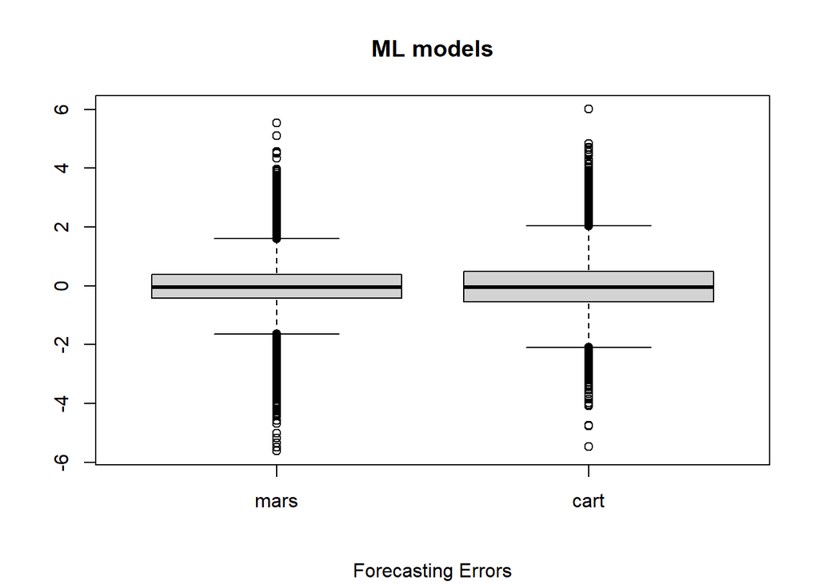

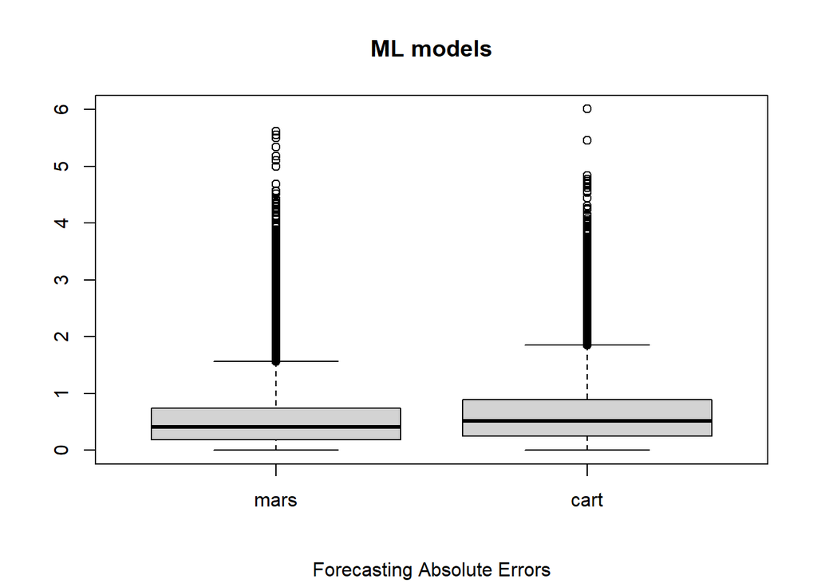

```
##       mars              cart
##  Min.   :0.00001   Min.   :0.000026
##  1st Qu.:0.18781   1st Qu.:0.246230
##  Median :0.40629   Median :0.520674
##  Mean   :0.53850   Mean   :0.651707
##  3rd Qu.:0.73799   3rd Qu.:0.888874
##  Max.   :5.61535   Max.   :6.008277
```

Summary Statistics

| Variable | N | Mean | Std. Dev. | Min | Pctl. 25 | Pctl. 75 | Max |
| --- | --- | --- | --- | --- | --- | --- | --- |
| mars | 49679 | 0.54 | 0.5 | 0.0000096 | 0.19 | 0.74 | 5.6 |
| cart | 49679 | 0.65 | 0.56 | 0.000026 | 0.25 | 0.89 | 6 |

## Resumen

(1.0 puntos) Discuta de las ventajas de cada modelo y resuma sus aprendizajes principales en un máximo de 4 tablas o figuras. Redacte de manera concisa sus resultados tal como los reportaría a una contrparte técnica a cargo de tomar decisiones. Agregue cualquier conclusión o idea que le parezca relevante de comunicar.

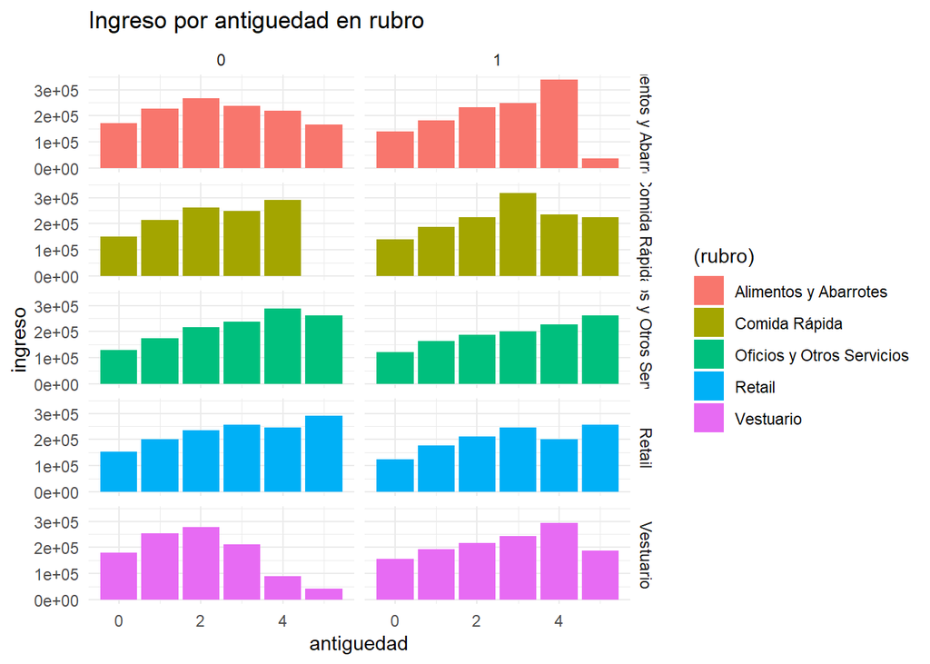

|  | M3 | M5 | M_1 | M_2 |
| --- | --- | --- | --- | --- |
| (Intercept) | 10.34***(0.01) |  | 8.61***(0.01) | -8.21***(0.05) |
| genero | -0.16***(0.01) | -0.12*(0.03) | -0.14***(0.00) | 0.13***(0.03) |
| hrs_trabajadas | 0.06***(0.00) | -0.01**(0.00) | -0.01***(0.00) |  |
| antiguedad | 0.13***(0.00) | 0.08*(0.02) | 0.06***(0.00) | 0.62***(0.02) |
| genero × hrs_trabajadas | 0.00***(0.00) |  | 0.00***(0.00) |  |
| log(transacciones) |  | 1.04***(0.01) | 1.04***(0.00) | 9.84***(0.01) |
| rubroComida Rápida |  |  | 0.20***(0.01) | -3.62***(0.08) |
| rubroOficios y Otros Servicios |  |  | 0.79***(0.01) | -0.32***(0.07) |
| rubroRetail |  |  | 0.48***(0.01) | -1.57***(0.06) |
| rubroVestuario |  |  | 1.03***(0.01) | -1.80***(0.11) |
| antiguedad × rubroComida Rápida |  |  | 0.06***(0.00) | -0.77***(0.05) |
| antiguedad × rubroOficios y Otros Servicios |  |  | 0.09***(0.00) | -0.78***(0.04) |
| antiguedad × rubroRetail |  |  | 0.01**(0.00) | -0.48***(0.04) |
| antiguedad × rubroVestuario |  |  | -0.07***(0.01) | -0.69***(0.07) |
| Num.Obs. | 234335 | 234335 | 234335 | 234335 |
| R2 | 0.492 | 0.748 | 0.749 | 0.782 |
| R2 Adj. | 0.492 | 0.748 | 0.749 | 0.782 |
| RMSE | 1.03 | 0.73 | 0.73 | 7.33 |

Vemos que el modelo M_2 que busca predecir el ingreso por hora es el que posee mejor poder explicativo. Si bien no predice la variable de ingreso total, si predice la de ingreso por hora lo que construye el ingreso total. Se observa que la cantidad de horas no genera la diferencia de ingresos entre sexos y todo indica que el número de transacciones es el mayor explicador de diferencias en el ingreso por hora y total. Los rubros con mayor influencia en disminuir el ingreso por hora son comida rápida seguido de vestuario, luego retail y por último oficios y otrs oficios. Las diferencias de ingreso por género provienen mayormente de una difenrencia en la cantidad máxima de transacciones, factor que puede verse influido pr rubro siendo los rubros en dónde cada transaccion es menor los que tienden a generar menor ingreso.  
A su vez, se observa que el factor del género puede estar generando la diminusión en el número de transacciones.  
Después de todo se concluye que la diferencia del 13.4% entre ingreso de hombres y mujeres no se puede explicar del todo con estos datos, sin embargo se sabe que proviene de diferencias al interior de cada rubro asociadas a cada sexo las cuales afectan el número de transacciones totales. Así, una estraegia para aumentar el ingreso es dedicarse a rubros en dónde el pago promedio sea mayor como oficios y otros servicios. De esta manera se disminuye el efecto del número de transacciones en el ingreso y por lo tanto se disminuye el efecto de la brecha de género.  
Podemos hacer conjeturas en la diferencia de transacciones producida en el rubro de comida rápida por ejemplo. Se puede deber a dificultades para trabjar en horarios más prodictivos como horas punta por parte de mujeres ya que pueden necesitar ir a dejar y buscar sus hijos al colegio, puede ser por una peor posicionamiento en la ciudad producto de que el hombre lucha más por los espacios. Estos son solo algunas posibilidades pero sólo con estos datos es dificil entender cual es la raíz del problema.  
Se propone hacer un estudio específicamente sobre que factores hacen que una persona realice más transacciones y las diferencias entre cada genero al realizar esas acciones, buscando casusas de porque un genero las realiza con mayor éxito que el otro.

Summary Statistics

| Variable | N | Mean | Std. Dev. | Min | Pctl. 25 | Pctl. 75 | Max |
| --- | --- | --- | --- | --- | --- | --- | --- |
| mars | 49679 | 0.54 | 0.5 | 0.0000096 | 0.19 | 0.74 | 5.6 |
| cart | 49679 | 0.65 | 0.56 | 0.000026 | 0.25 | 0.89 | 6 |

En este caso, tenemos que comparando, MARS produce el menor error. Es posible que con diferentes modelos con más parámetros esto varíe. Es posible también modificar los parámetros a los que se somete el entrenamiento, así como la distribución de los datos de entrenamiento y testeo.

## Anexos

Documenta acá cualquier otro adicional que consideres útil tener de referencia.